# lab6

Abeoseh Flemister

2026-04-09

Read in data

```r
temp <- tempfile()
download.file("http://afodor.github.io/classes/stats2015/longitdunalRNASeqData.zip", temp)

counts <- read.table(unz(temp, "nc101_scaff_dataCounts.txt"),  sep = "\t", header = TRUE, row.names = 1)

annotations <- read.table(unz(temp, "nc101_Annotations.txt"),  sep = "\t", header = TRUE, row.names = 1)
unlink(temp)

print(head(counts))
```

```
##             D2_01 D2_02 D2_03 W12_01 W12_02 W12_03 w20_01 w20_02 w20_03 w20_04
## NC101_00003   329    29    40     97    423    141    469    342    884    713
## NC101_00004    30     2     6      7     83     34     76     45    131    127
## NC101_00005   145    53    23    122    271    128    102     57    134    112
## NC101_00006   510    80    54    156    717    193    489    228    536    487
## NC101_00007     5     3     0     13     25      1      9      2     30      9
## NC101_00008    14     4     2      8     65     14    208     82    302    241
##             w20_05
## NC101_00003     52
## NC101_00004     65
## NC101_00005     13
## NC101_00006     57
## NC101_00007     11
## NC101_00008     14
```

```r
print(head(annotations))
```

```
##             nc101_code.1     Ref.Seq.ID                       Annotation
## NC101_00003  NC101_00003 YP_006101209.1 SEC-C domain-containing protein
## NC101_00004  NC101_00004 YP_006101208.1               tyrP gene product
## NC101_00005  NC101_00005 YP_006101207.1            hypothetical protein
## NC101_00006  NC101_00006 YP_006101206.1               ftnA gene product
## NC101_00007  NC101_00007 YP_006101204.1            putative lipoprotein
## NC101_00008  NC101_00008 YP_006101202.1            hypothetical protein
```

Remove rare genes and normalize

```r
counts <- counts[ apply( counts, 1, median)> 5,]

CountsNorm <- counts
for ( i in 1:ncol(counts))
{
    colSum = sum(counts[,i])
    CountsNorm[,i] = CountsNorm[,i]/colSum
}
```

(The first 3 columns are “day 2”, the next 3 columns are “week 12” and the last 5 are “week 18” (even though they say w20)).

1. For each row in the spreadsheet, perform a one-way ANOVA with categories “day 2”, “week 12” and “week 18”. Plot out the histogram of all p-values. How many genes are significant at a BH FDR-corrected 0.05 threshold.

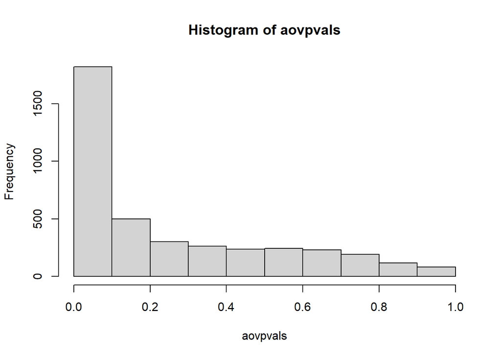

```r
categories <- c(rep("D2",3), rep("W12",3), rep("W20",5))
categories <- factor(categories)
aovpvals <- vector(length = nrow(CountsNorm) )

aov1_index = vector(length = nrow(CountsNorm) )

for (i in 1:nrow(CountsNorm)){

  linear_reg <- lm( as.numeric(CountsNorm[i,]) ~ categories )

  aovpvals[i] <- anova(linear_reg)[["Pr(>F)"]][1]


  }


hist(aovpvals)
```

```r
sig = p.adjust(aovpvals, method = "BH")
print(paste(sum(sig < 0.05),"p-vlaues are significant after benjamin hochberg correction"))
```

```
## [1] "612 p-vlaues are significant after benjamin hochberg correction"
```

```r
aov1_df <- data.frame()
```

1. Next make an ANOVA as a linear regression as a function of time (so 2 days, 86 days and 128 days). Plot out the histogram of all p-values. How many genes are significant at a BH FDR-corrected 0.05 threshold.

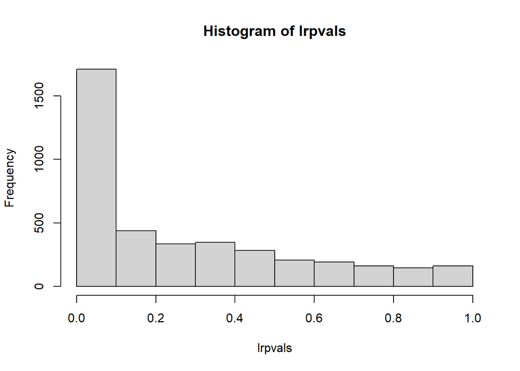

```r
days <- c(rep(2,3), rep(86,3), rep(128,5))
lrpvals <- vector(length = nrow(CountsNorm) )


for (i in 1:nrow(CountsNorm)){

  linear_reg <- lm( as.numeric(CountsNorm[i,]) ~ days )

  lrpvals[i] <- anova(linear_reg)[["Pr(>F)"]][1]

  }


hist(lrpvals)
```

```r
sig = p.adjust(lrpvals, method = "BH")
print(paste(sum(sig < 0.05),"p-vlaues are significant after benjamin hochberg correction"))
```

```
## [1] "448 p-vlaues are significant after benjamin hochberg correction"
```

```r
most_sig2 = row.names(CountsNorm)[ which( sig == min(sig) ) ]
```

3. Finally, for each row in the spreadsheet perform an ANVOA comparing the three-parameter model from (A) and the two parameter model from (B). Plot out the histogram of all p-values. For how many genes is there a significant difference between these two models at a BH FDR-corrected threshold.

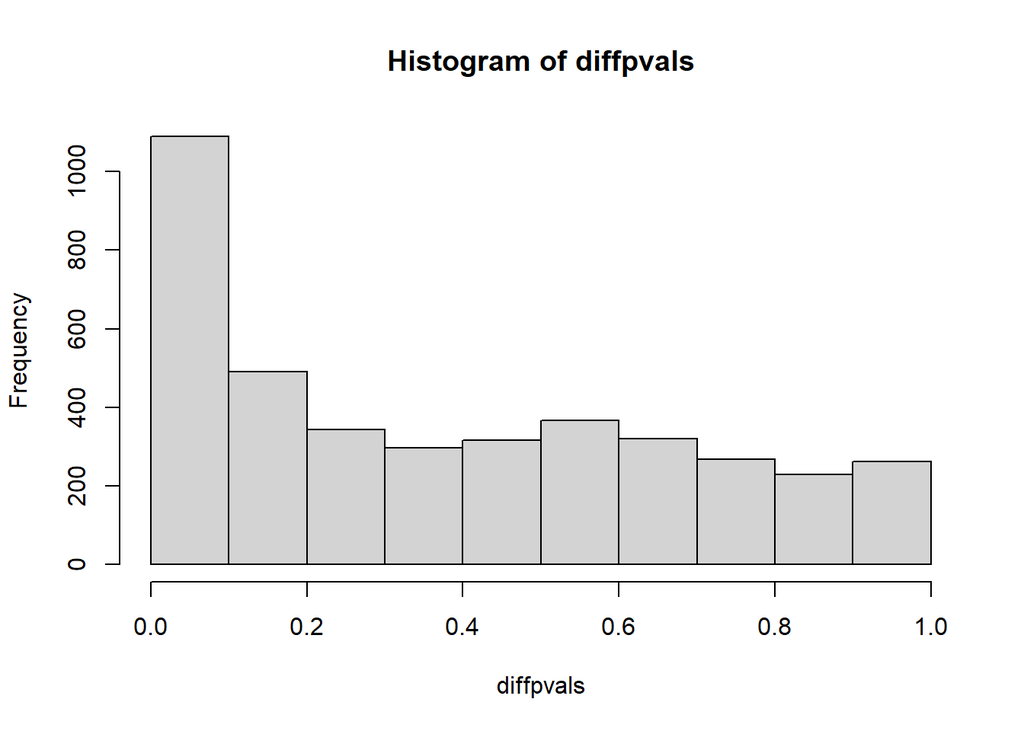

```r
## make the reduced model the linear model.
categories <- c(rep("D2",3), rep("W12",3), rep("W20",5))
categories <- factor(categories)

days <- c(rep(2,3), rep(86,3), rep(128,5))


diffpvals <- vector(length = nrow(CountsNorm) )


for (i in 1:nrow(CountsNorm)){


  FullModel <- lm( as.numeric(CountsNorm[i,]) ~ categories )
  FullResiduals <- sum( residuals(FullModel) ^ 2 )

  ReducedModel <- lm( as.numeric(CountsNorm[i,]) ~ days )
  ReducedResiduals <- sum( residuals(ReducedModel) ^ 2 )

  ## df  = # data points - # params
  ## df in reduced = 11 - 2 = 9
  ## df in full = 11 - 3 = 8

  F_value <- ( (ReducedResiduals - FullResiduals) / (9 - 8) ) / (FullResiduals / 8)

  diffpvals[i] <- pf(F_value, (9-8), 8, lower.tail = F)
  }


hist(diffpvals)
```

```r
sig = p.adjust(diffpvals, method = "BH")
print(paste(sum(sig < 0.05),"p-vlaues are significant after benjamin hochberg correction"))
```

```
## [1] "51 p-vlaues are significant after benjamin hochberg correction"
```

```r
most_sig3 = row.names(CountsNorm)[ which( sig == min(sig) ) ]
```

4. Make three graphs showing the relative abundance of the most significant gene under each of the three ANOVA models. For (A) and (C), the x-axis will the category (day 3, week 12 and week 18) and the y-axis will be the relative abundance. Be sure to properly label and title all graphs and axes. For (B) the x-axis will be time (in days) and the y-axis will be the relative abundance. For the graph of the top hit from (B), include the regression line for the plot from (B).

**Compare ANOVA models:**

```r
df <- data.frame(index = 1:nrow(CountsNorm), anova = aovpvals, lr = lrpvals,  diff = diffpvals)

head(df)
```

```
##   index        anova          lr        diff
## 1     1 0.9100144653 0.754077180 0.763454243
## 2     2 0.2975763978 0.117279334 0.734542332
## 3     3 0.0006747441 0.028396643 0.001993919
## 4     4 0.0087588766 0.005113998 0.155630072
## 5     5 0.3013518244 0.890539086 0.134402540
## 6     6 0.0271221645 0.023800039 0.130603110
```

**ANOVA model 1:**

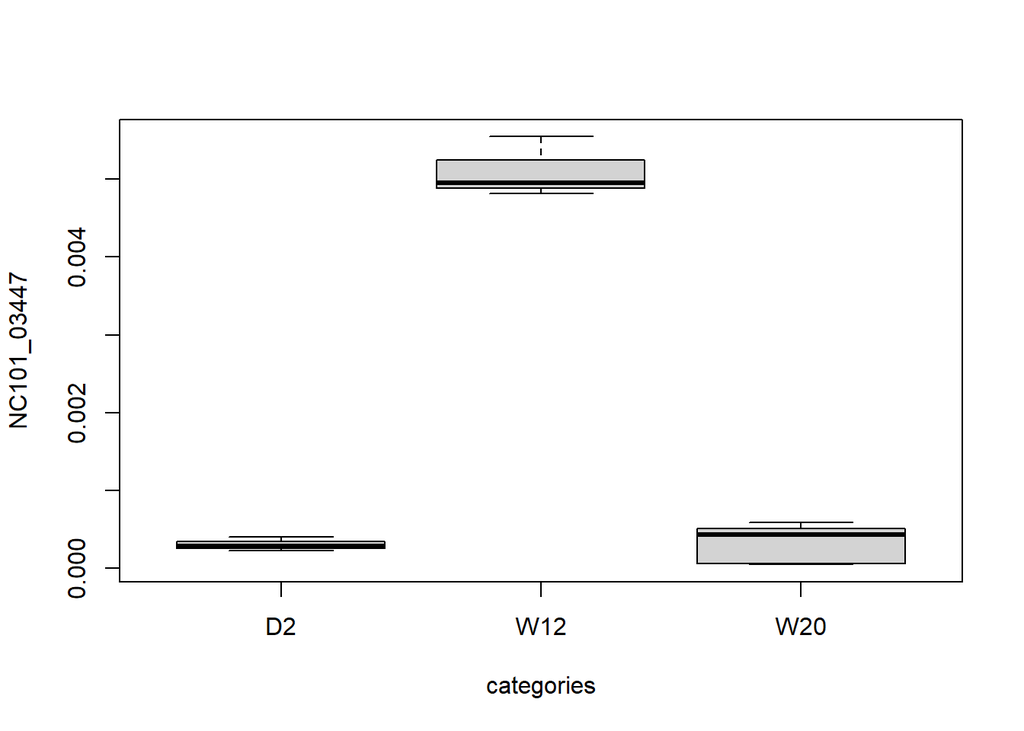

```r
df <- df[ order(df$anova), ]

boxplot( as.numeric( CountsNorm[ df$index[1],]) ~ categories, ylab = row.names(CountsNorm[ df$index[1],]) )
```

**ANOVA model 2**

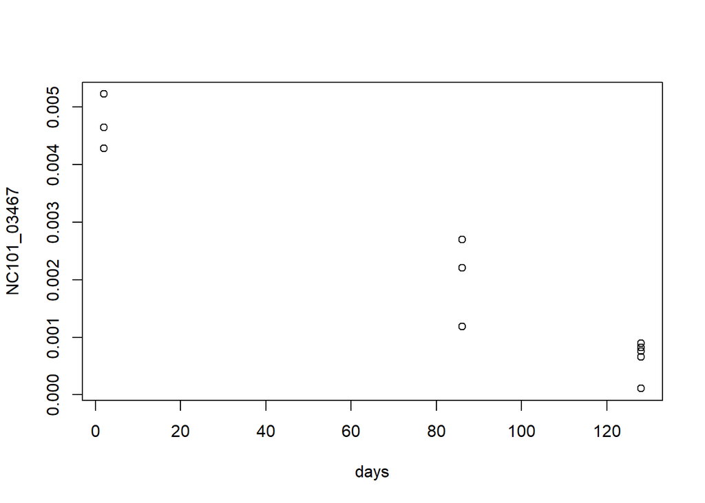

```r
df <- df[ order(df$lr), ]

plot( as.numeric( CountsNorm[ df$index[1],]) ~ days, ylab = row.names(CountsNorm[ df$index[1],]) )
```

**ANOVA model 3**

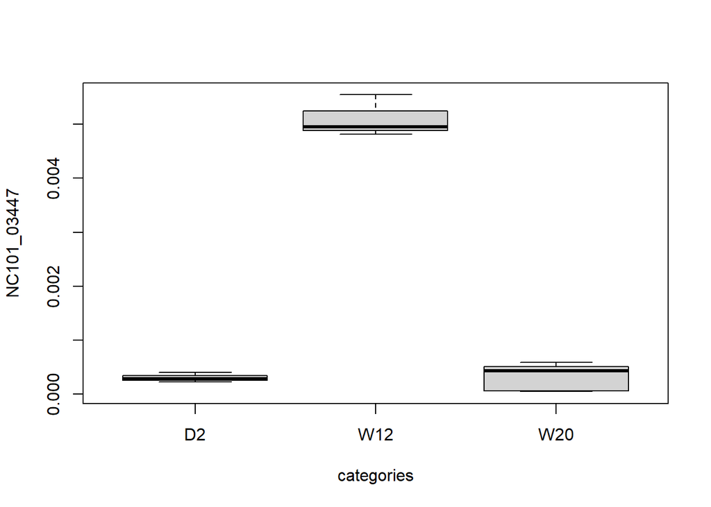

```r
df <- df[ order(df$diff), ]

boxplot( as.numeric( CountsNorm[ df$index[1],]) ~ categories, ylab = row.names(CountsNorm[ df$index[1],]) )
```

5. Overall, do you think the three parameter model in (A) or the two-parameter model in (B) is more appropriate for these data? Justify your answer.

**The three parameter model has the null that the mean of the three time periods are equal, meaning that the three time periods have similar levels of relative abundance for the gene. One of the assumptions of the two parameter (linear) model is linearity. This assumption is not true for all the genes. For instance,** **with gene** **NC101_03447 there is not a linear relationship between the relative abundance and time since the relative abundance rises in the middle. Therefore, the three parameter model is more appropriate for the data.**